# Quality control for plates

Andrea Villanueva Raisman

# Data distribution and outliers

In the first histogram, by looking at the normalized area of the peptide intensity peaks, we can assess if they follow a normal distribution. All histograms shows a skewed central tendency because of the many, very low values, which also indicate potential outliers. However, there do not seem to be gaps in the data for any of the plates. The boxplots facilitate the identification of the outliers and display their relative distance from the bulk of the data, making it easier to compare distribution across the samples and the plates.

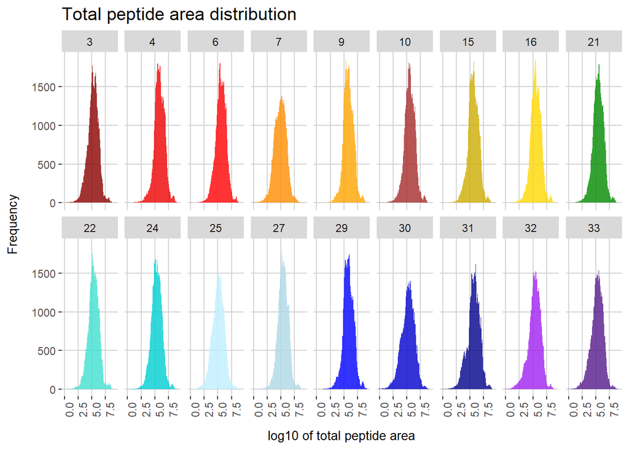

The outliers shown by the boxplot can be the result of bad peak integration. In some cases, this can be the result of incorrect peak integration which can be corrected manually. Skyline’s results have not been manually revised for this plate yet due to time constraints, but the most extreme outliers most probably belong to heavy isotopes which have not detected.

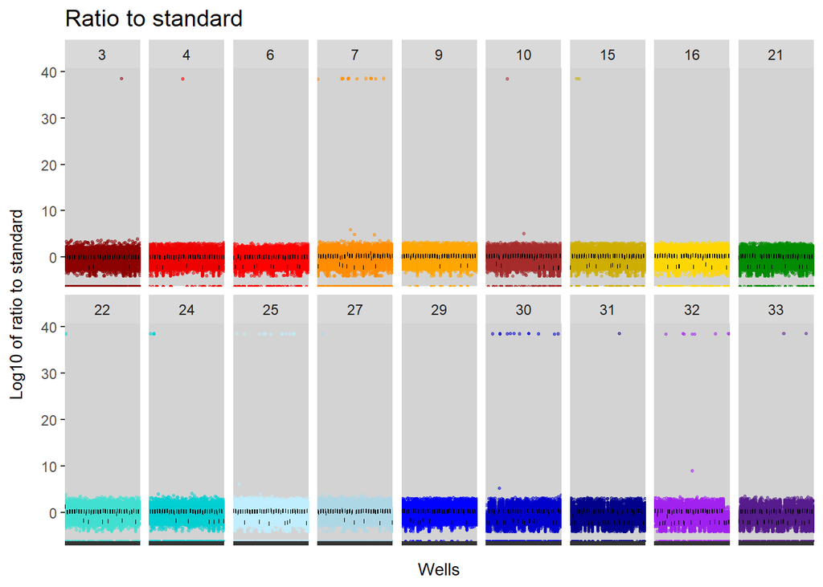

We proceed by filtering the peptides whose dotp product is low. The thresold here is dotp = 0.80. However, the report might be improved later after manually re-integrating peaks. The histograms now show a less skewed central tendency because many of the low values were due to poor integration. If this is not aparent in the histograms, the table shows the numerical values of the median of the total area per plate and the difference between them. The third column is the result of substracting the median of the raw data from the filtered data. In all cases, the difference is positive, meaning that filtering the data increased the median in all plates.

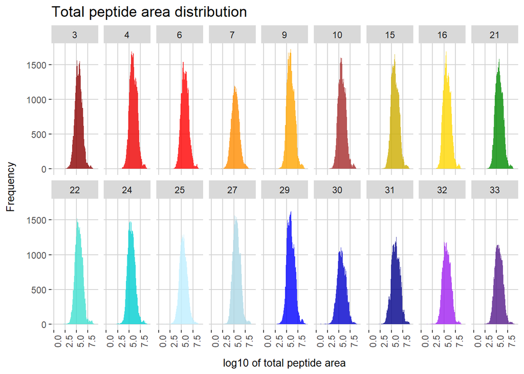

**Median comparison table: before and after low dotp filtering**

```
##    Plate Raw data median Filtered data median Median difference
## 1     10        329752.5             428100.5           98348.0
## 2     15        433605.5             548408.0          114802.5
## 3     16        342086.5             434100.5           92014.0
## 4     21        283061.5             378356.5           95295.0
## 5     22        213889.5             312726.5           98837.0
## 6     24        216333.5             314558.5           98225.0
## 7     25        128080.0             248449.0          120369.0
## 8     27        256111.5             345866.5           89755.0
## 9     29        659479.0             799689.0          140210.0
## 10     3        187391.5             295647.0          108255.5
## 11    30        179113.0             364524.0          185411.0
## 12    31        554042.5             828669.0          274626.5
## 13    32        239414.5             385099.5          145685.0
## 14    33        189046.0             312893.0          123847.0
## 15     4        696797.5             838573.5          141776.0
## 16     6        379718.5             536821.0          157102.5
## 17     7         84172.0             194990.0          110818.0
## 18     9        652612.5             774092.5          121480.0
```

Similarly, the most extreme outliers have disappeared from the boxplots. What now becomes visible is that there are samples with much lower medians than the rest in all plates too. However, the number of low-median samples per plate dramatically increses in plates 30 to 33. This might be due to the failure detected in the robotics equipment around the time that these samples were being prepared for the mass spectrometer.

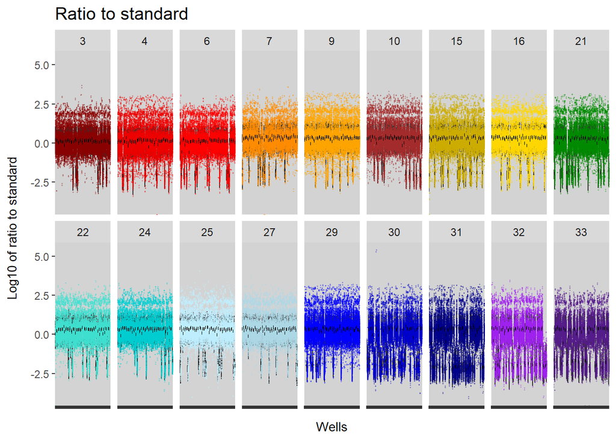

## Counts

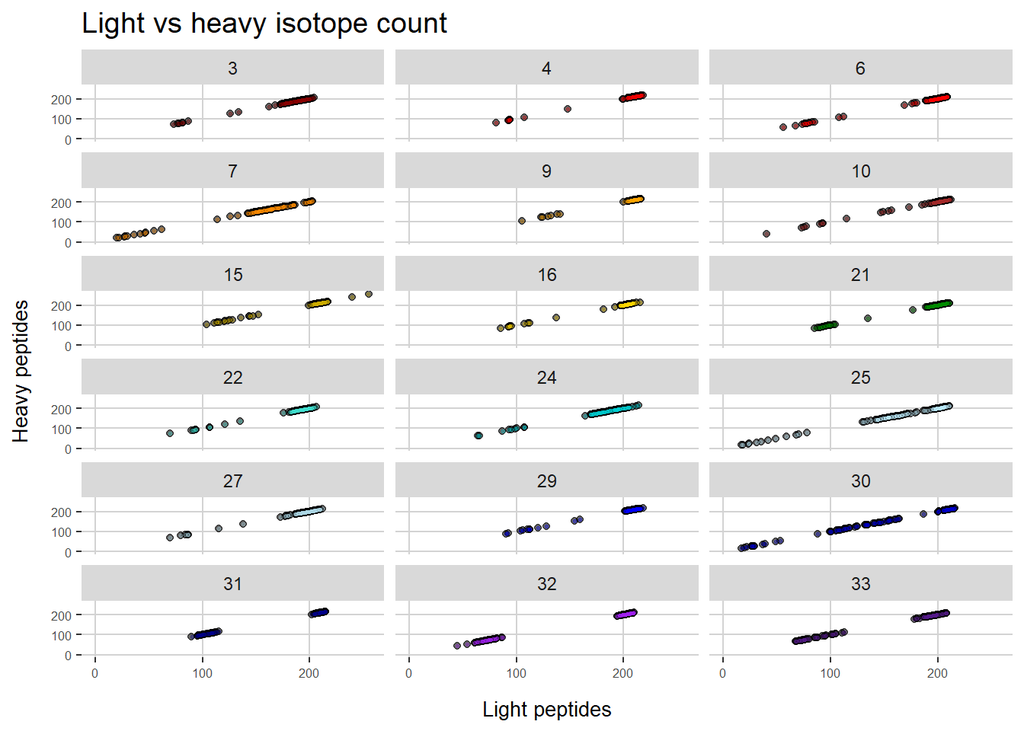

The subsequent step in the analysis involves filtering samples based on two criteria: peptide count and the median of their ratios to the standard. This dual filtration approach is adopted to ensure a robust selection of samples that exhibit both a significant number of detected peptides and a consistent ratio to the standard across proteins.

The criteria involve retaining samples from the plate reports where a minimum of 75 out of 117 proteins were detected. Additionally, we filter samples based on a criterion where the median of the log10-transformed ratios to the standard exceeds -0.5. Although the protein count threshold predominantly filters out samples with lower medians, some samples with medians close to this threshold may persist. Filtering by median values allows to specifically target and exclude these samples, ensuring a more stringent selection.

Employing both filters serves as a means of reinforcing the selection process. The combined approach ensures that samples exhibiting a low peptide count or potentially deviating median values are excluded, which could otherwise introduce bias or skewness in subsequent analyses. Moreover, employing only the peptide count as a filter might retain samples with a higher number of detected peptides but significantly lower peptide intensities. Such samples may reflect non-biological processes or technical artifacts, warranting further investigation in subsequent analyses.

Visualizing the resulting filtered dataset using the same boxplot reveals a more regular distribution among the retained samples. This filtration process helps in ensuring a dataset with a more consistent and reliable distribution for subsequent analyses.

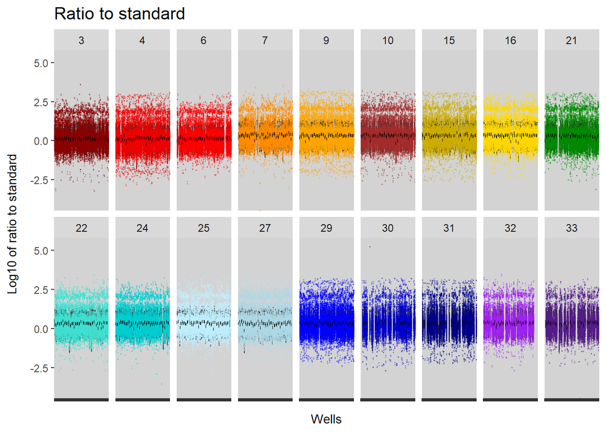